# Cruise Ships’ Impact on NYC Air Quality

2023-12-04

## Introduction

- Air Pollution is responsible for an estimated 6.7 million annual premature deaths globally (WHO, 2022).
- Cruise ship emissions are a visible source of urban pollition in coastal cities, with increasing attention to mitigation strategies like the use of on-shore power while in port
- *Research Gap*: Lack of empirical analysis in the context of New York City, emphasizing the need for a data-driven approach.

## Study Area: Brooklyn Cruise Terminal

- Only terminal on the east coast with shore power system designed to reduce emissions
- Installed in 2016 at the cost of $21M
- Red Hook neighborhood has worst air quality in Brooklyn (NYC.gov, 2023)
- Policy Context: New York City considering local law Int. 1050, requiring cruise ships to use on-shore power by 2028 at all ports (including Manattan Cruise Terminal)

## Research Questions

- What level of expected improvement in air quality can be expected as a result of improvements to New York City cruise ship terminals and proposed new regulations that will require all cruise ships to use on-shore power by 2028?
- What feature set among available inputs will best predict air quality *in the absence of consideration of cruise ship inputs*?
- Does the inclusion of cruise ship features measurably improve these results?

## Literature Review

- Selection of PM 2.5 as a critical parameter due to its known health impacts and reliable measurement methods
- Methodological research included use of circular data (wind direction) and PM 2.5 readings from Purple Air
- Studies from Europe (Hrvoje, 2011; Ruiz-Guerra et al, 2019; Fabregat et al, 2021) and Canada (Poplawski et al, 2011) support cruise ship emissions as measurably impacting on-shore air quality, typically using linear regression
- No studies found to document this relationship in New York City, or using non-parametric methods to identify feature set

## Data Sources

- Weather and airquality data at the Port is taken from a Dyson Instruments weather station located adjacent to the Brooklyn Cruise Terminal
- Observations are taken in 15 minute increments, starting July 11, 2023
- Ship docking data is taken from Port of New York, hourly, and the EDC for information on whether ships can access the on-shore power or must use the generator (all ships outside of BCT use generators)
- Additional data taken from Purple Air sensor at Dyberry farm as a control for wildfire smoke

## Data Preparation

- Weather data features evaluated include temperature, dew point, heat bulb index, humidity, wind speed, wind direction, air pressure reported at average, low, and high as well as rain in inches
- Highly correlated weather features pruned to include only average value
- Wind direction converted to radians and then defined by the sine and cosine of theta to avoid correlation
- Cruise ship compatibility is taken from the EDC and extrapolated to ship dockings in July
- PM 2.5 levels from Purple Air corrected based on EPA
- Weather data aggregated hourly (average value, except for rain which is summed) to join with cruise ship data and control sensor data from Purple Air
- Final data set has 17 features, 5 possible targets, and 3,396 observations across 141 days (some days contain more than 24 observations because there may be more than one ship present)

## Time Series

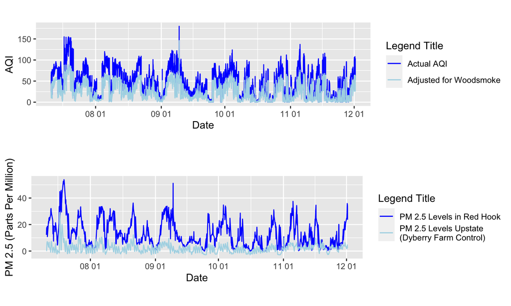

## Data Exploration

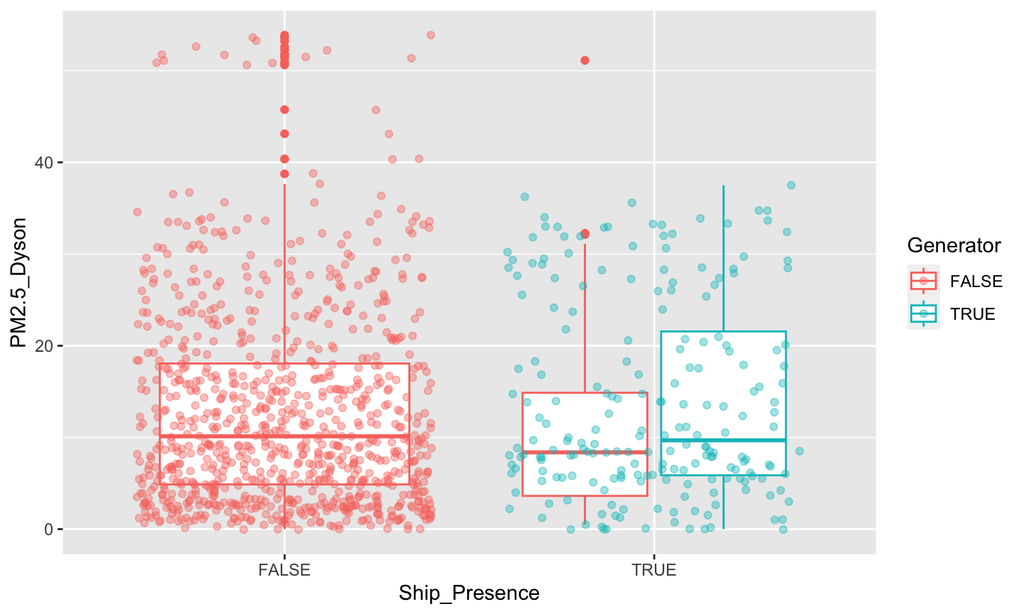

## Data Exploration

```
## # A tibble: 3 × 7
## # Groups:   Ship_Presence [2]
##   Ship_Presence Generator   PM1 PM2.5  PM10   AQI `AQI Adj.`
##   <lgl>         <lgl>     <dbl> <dbl> <dbl> <dbl>      <dbl>
## 1 FALSE         FALSE      9.32  13.1  14.4  44.4       24.7
## 2 TRUE          FALSE      7.81  10.7  11.7  37.4       20.8
## 3 TRUE          TRUE      10.1   13.9  15.2  46.8       26.2
```

[output not shown]

[output cut: 1064 more lines]